# Data distributions where Kmeans clustering fails; can DBSCAN or hierarchical clustering be solutions?

For Kmeans clustering to work well, the following assumptions have to hold true:

- the variance of the distribution of each attribute (variable) is spherical
- all variables have the same variance
- the prior probability for all k clusters are the same, i.e. each cluster has roughly equal number of observations;

If any one of these 3 assumptions is violated, then k-means does not do a good job.

Let's see with example data and explore if DBSCAN or hierarchical clustering can be a solution.

This is the R-only version of my blog post ([link](https://datascience-enthusiast.com/Python/DBSCAN_Kmeans.html)) which was done with R, Python and Spark.

## Clusters with uneven sizes

As shown below, Kmeans does not work well with unevenly sized clusters.

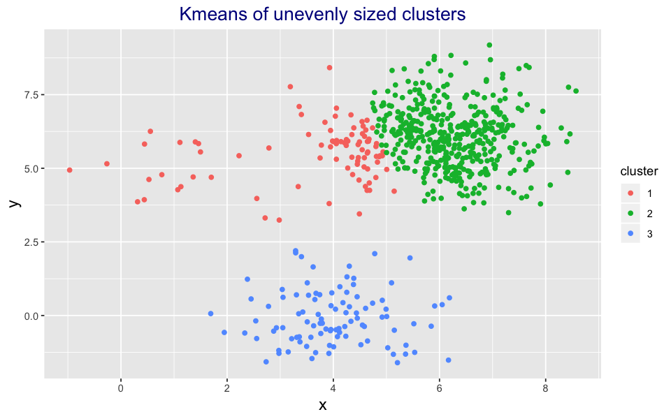

```r
library(tidyverse)
library(dbscan)
library("fpc")
library(factoextra)
options(repr.plot.width=8, repr.plot.height=5)

set.seed(123)   #for reproducibility
sizes <- c(20, 100, 500)
centers <- data_frame(x = c(1, 4, 6), y = c(5, 0, 6), n = sizes,
                      cluster = factor(1:3))
df1 <- centers %>% group_by(cluster) %>%
    do(data_frame(x = rnorm(.$n, .$x), y = rnorm(.$n, .$y)))

km<- kmeans(df1, centers= 3)
df1$cluster = as.character(km$cluster)
df1 %>% ggplot(aes(x = x, y = y, color  = cluster)) + geom_point() +
          ggtitle('Kmeans of unevenly sized clusters') +
          theme(axis.title = element_text(size=14), plot.title =
            element_text(size = 16,colour="darkblue",hjust = 0.5))
```

## Non-spherical distribution

Since KMeans assumes spherical data distribution, as shown below, it does not work with non-spherical data.

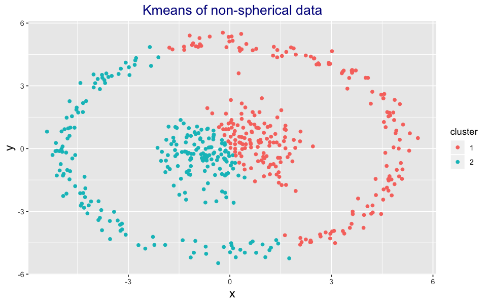

```r
set.seed(134)
n <- 250
c1 <- data_frame(x = rnorm(n), y = rnorm(n))
c2 <- data_frame(r = rnorm(n, 5, .25), theta = runif(n, 0, 2 * pi),
                 x = r * cos(theta), y = r * sin(theta)) %>% dplyr::select(x, y)

df2 <- rbind(c1, c2)
km<- kmeans(df2, 2, nstart = 25)
df2$cluster = as.character(km$cluster)
df2 %>% ggplot(aes(x = x, y = y, color  = cluster)) + geom_point() +
        ggtitle('Kmeans of non-spherical data') +
          theme(axis.title = element_text(size=14), plot.title =
            element_text(size = 16,colour="darkblue",hjust = 0.5))
```

## Non-spherical data with outliers

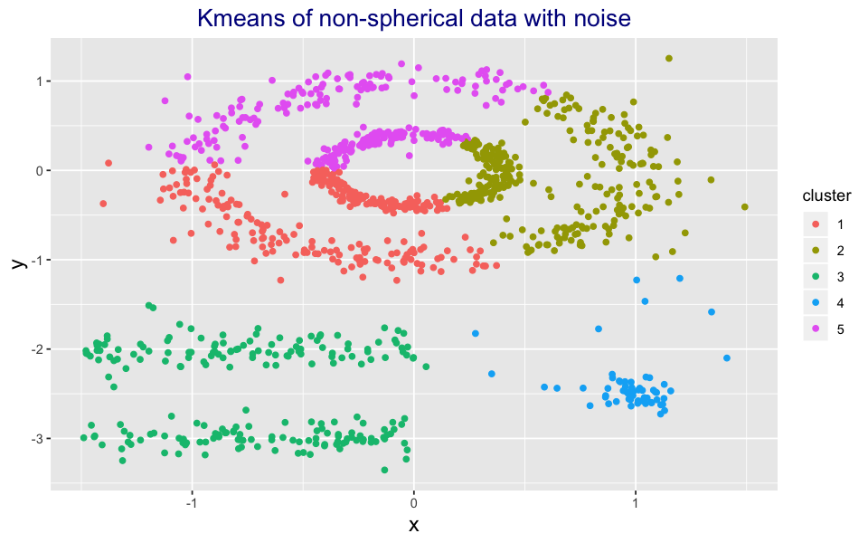

```r
data("multishapes")
df3 <- multishapes[, 1:2]
km<- kmeans(df3, 5, nstart = 25)
df3$cluster = as.character(km$cluster)
df3 %>% ggplot(aes(x = x, y = y, color  = cluster)) + geom_point() +
       ggtitle('Kmeans of non-spherical data with noise') +
          theme(axis.title = element_text(size=14), plot.title =
            element_text(size = 16,colour="darkblue",hjust = 0.5))
```

### DBSCAN

Now, let's see if DBSCAN can fix the problems above.

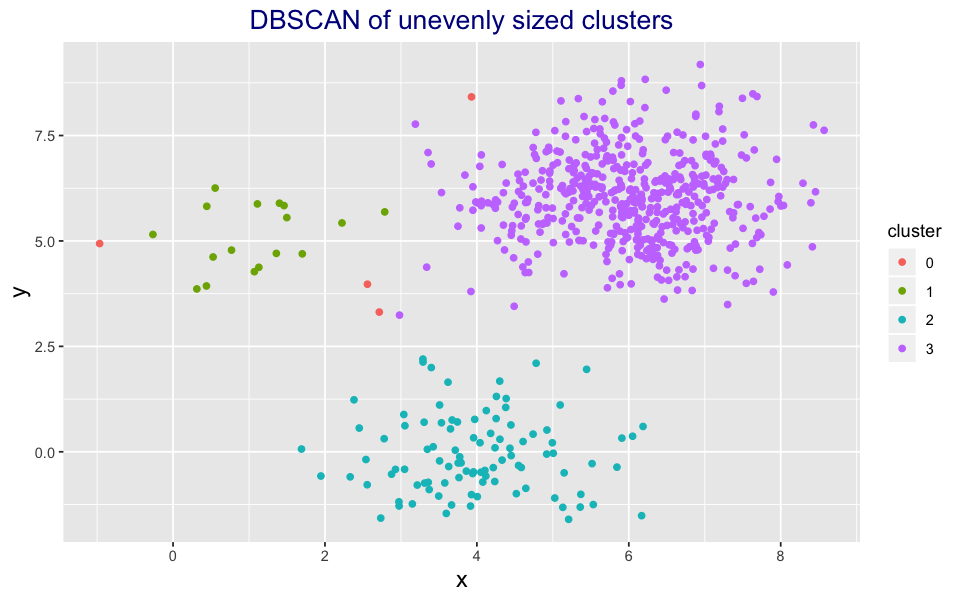

```r
df1 = data.frame(x = df1$x, y = df1$y)
db <- fpc::dbscan(df1 , eps = 1.1, MinPts = 6)
df1$cluster = as.character(db$cluster)
df1 %>% ggplot(aes(x = x, y = y, color  = cluster)) + geom_point() +
       ggtitle('DBSCAN of unevenly sized clusters') +
          theme(axis.title = element_text(size=14), plot.title =
            element_text(size = 16,colour="darkblue",hjust = 0.5))
```

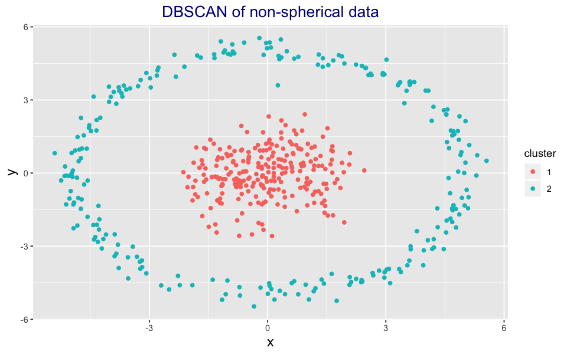

```r
df2 = df2 %>% select(x, y)
db <- fpc::dbscan(df2, eps = 1.1, MinPts = 6)
df2$cluster = as.character(db$cluster)
df2 %>% ggplot(aes(x = x, y = y, color  = cluster)) + geom_point() +
        ggtitle('DBSCAN of non-spherical data') +
          theme(axis.title = element_text(size=14), plot.title =
            element_text(size = 16,colour="darkblue",hjust = 0.5))
```

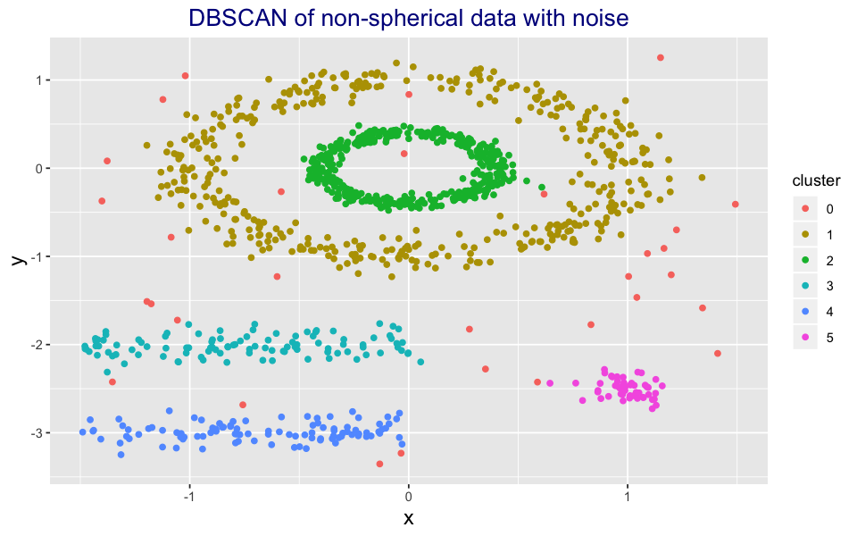

```r
df3 = df3 %>% select(x, y)
db <- fpc::dbscan(df3, eps = 0.15, MinPts = 5)
df3$cluster = as.character(db$cluster)
df3 %>% ggplot(aes(x = x, y = y, color  = cluster)) + geom_point() +
        ggtitle('DBSCAN of non-spherical data with noise') +
          theme(axis.title = element_text(size=14), plot.title =
            element_text(size = 16,colour="darkblue",hjust = 0.5))
```

As shown above, DBSCAN gives meaningful clusters.

### Advantages of DBSCAN

1. DBSCAN does not require one to specify the number of clusters in the data a priori, as opposed to k-means.
2. DBSCAN can find arbitrarily shaped clusters.
3. DBSCAN has a notion of noise, and is robust to outliers.
4. DBSCAN requires just two parameters which can be set by a domain expert, if the data is well understood.

### Disadvantages of DBSCAN

1. The quality of DBSCAN depends on the distance measure used. The most common distance metric used is Euclidean distance. Especially for high-dimensional data, this metric can be rendered almost useless due to the so-called "Curse of dimensionality", making it difficult to find an appropriate value for ε (the maximum radius of the neighborhood from a point).
2. DBSCAN cannot cluster data sets well with large differences in densities, since the minPts-ε combination cannot then be chosen appropriately for all clusters. minPts is the minimum number of points required to form a dense region.
3. If the data and scale are not well understood, choosing a meaningful distance threshold ε can be difficult.

As you can see from the animation below, DBSCAN is sensitive to the parameters

```r
data("multishapes")

df <- multishapes[, 1:2]

n = 1
for(eps in seq(0.05, 0.15, 0.05)){
  for(minpPts in seq(2, 5, 1)){
    db <- fpc::dbscan(df, eps = eps, MinPts = minpPts)
    g = fviz_cluster(db, df, stand = FALSE, ellipse = FALSE, geom = "point") +
      ggtitle(paste0('eps = ', eps, ' minPts = ', minpPts)) +  theme(legend.position="none") +
      theme(axis.title = element_text(size=14), plot.title = element_text(size = 16,colour="darkblue",
                                                                    hjust = 0.5))
    ggsave(paste0('g',n,'.png'))
    n = n+1
  }}
system("convert -delay 200  -loop 0  *.png dbscan.gif")
file.remove(list.files(pattern=".png"))
```

[figure not shown]

### OPTICS

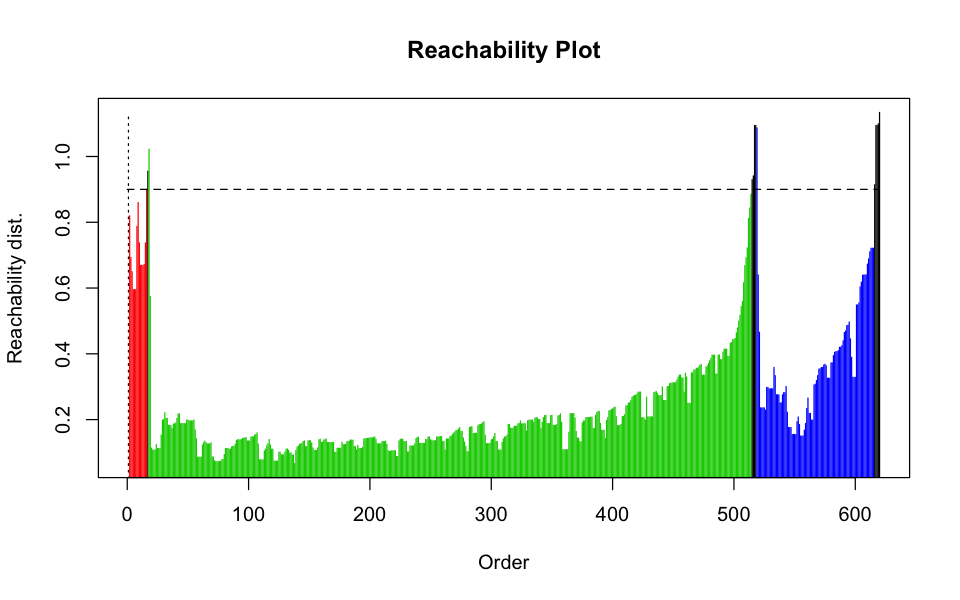

```r
library(dbscan)
df1 = data.frame(x = df1$x, y = df1$y)
res <- optics(df1, minPts = 5)
res <- extractDBSCAN(res, eps_cl = .9)
plot(res)
```

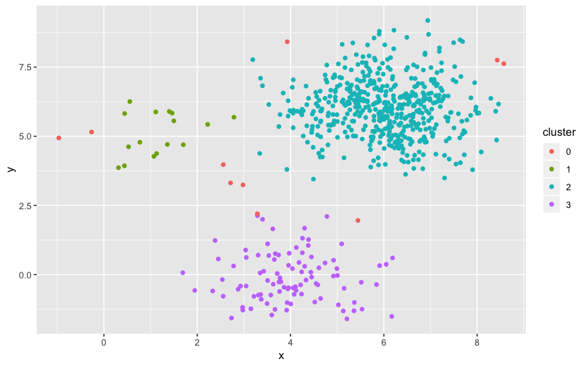

```r
df1$cluster = as.character(res$cluster)
df1 %>% ggplot(aes(x = x, y = y, color = cluster)) + geom_point()
```

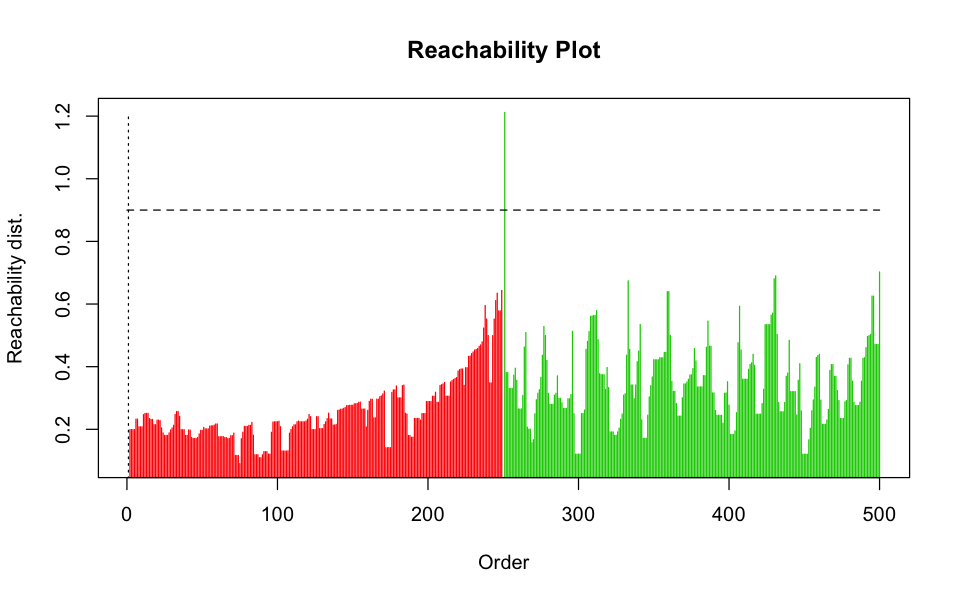

```r
df2 = data.frame(x = df2$x, y = df2$y)
res <- optics(df2, minPts = 5)
res <- extractDBSCAN(res, eps_cl = .9)
plot(res)
```

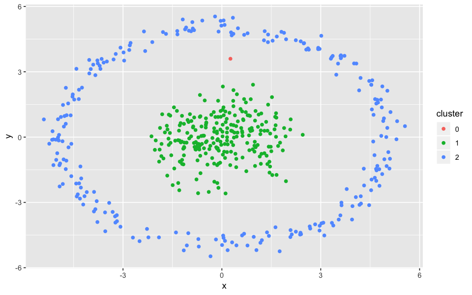

```r
df2$cluster = as.character(res$cluster)
df2 %>% ggplot(aes(x = x, y = y, color = cluster)) + geom_point()
```

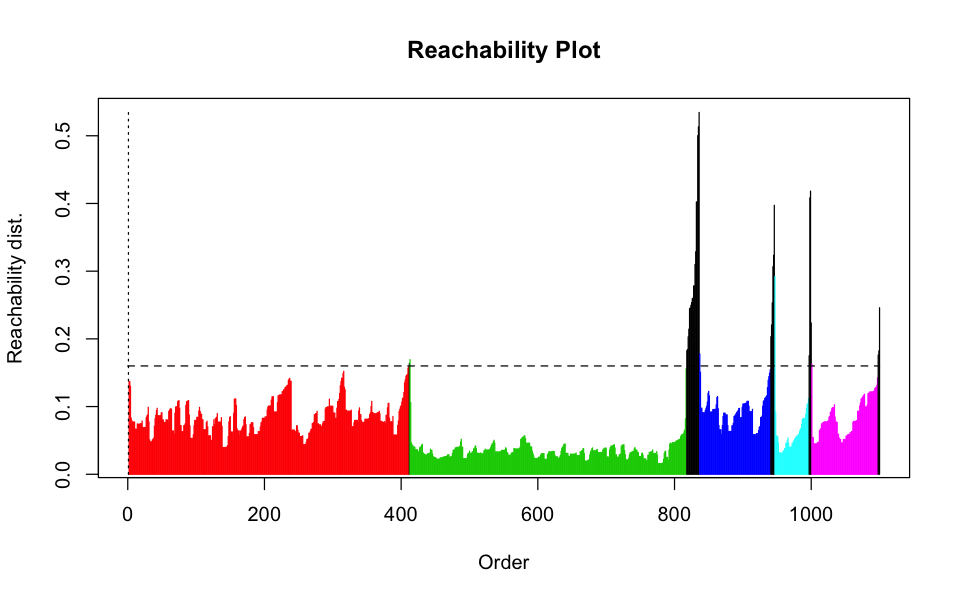

```r
df3 = data.frame(x = df3$x, y = df3$y)
res <- optics(df3, minPts = 6)
res <- extractDBSCAN(res, eps_cl = .16)
plot(res)
```

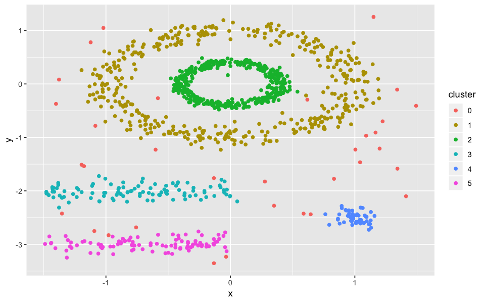

```r
df3$cluster = as.character(res$cluster)
df3 %>% ggplot(aes(x = x, y = y, color = cluster)) + geom_point()
```

## Hierachical clustering

I was asked to add Hierarchical clustering and to see how it compares. As you can see below, hierarchical clustering also fails to correctly identify the clusters of the last example. See I have used complete agglomeration method for the first example, single agglomeration method for the second method. For the last example, I have shown an animation with all the available distance and agglomeration calculation techniques.

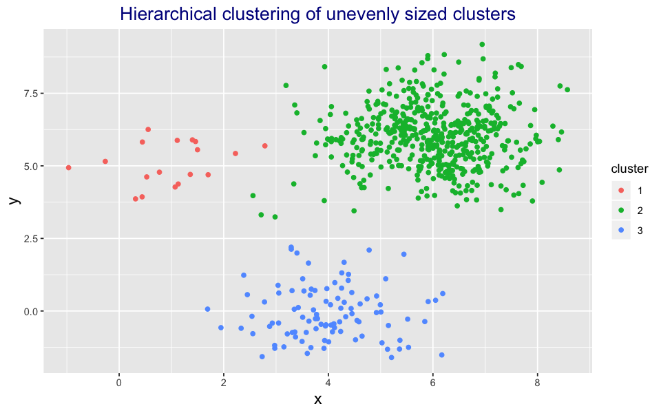

```r
library(dendextend)
df1 = df1 %>% select(x,y)
distances = dist(df1, method = "euclidean")
clusterdf = hclust(distances, method = "complete")
df1$cluster= as.character(cutree(clusterdf, k = 3))
df1 %>% ggplot(aes(x = x, y = y, color  = cluster)) + geom_point() +
          ggtitle('Hierarchical clustering of unevenly sized clusters') +
          theme(axis.title = element_text(size=14), plot.title =
            element_text(size = 16,colour="darkblue",hjust = 0.5))
```

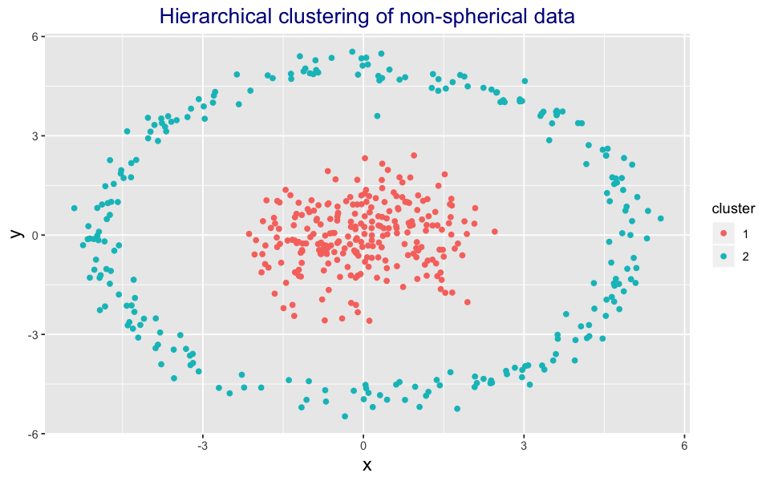

```r
df2 = df2 %>% select(x, y)
distances = dist(df2, method = "euclidean")
clusterdf = hclust(distances, method = "single")
df2$cluster= as.character(cutree(clusterdf, k = 2))
df2 %>% ggplot(aes(x = x, y = y, color  = cluster)) + geom_point() +
        ggtitle('Hierarchical clustering of non-spherical data') +
          theme(axis.title = element_text(size=14), plot.title =
            element_text(size = 16,colour="darkblue",hjust = 0.5))
```

```r
distance_methods = c("euclidean", "maximum", "manhattan", "canberra", "binary", "minkowski")
hclust_methods = c("ward.D", "ward.D2", "single", "complete", "average", "mcquitty", "median","centroid")

n = 1
for(distance_method in distance_methods){
  for(hclust_method in hclust_methods){
      df3 = df3 %>% select(x, y)
      distances = dist(df3, method = distance_method)
      clusterdf = hclust(distances, method = hclust_method)
      df3$cluster= as.character(cutree(clusterdf, k = 5))
      g = df3 %>% ggplot(aes(x = x, y = y, color  = cluster)) + geom_point() +
      ggtitle(paste('Hierarchical clustering: ','\ndistance measure = ', distance_method ,',\nagglomeration method = ', hclust_method)) +
          theme(axis.title = element_text(size=14), plot.title =
            element_text(size = 16,colour="darkblue",hjust = 0.5))

    ggsave(paste0('g',n,'.png'))
    n = n+1
  }}
system("convert -delay 150  -loop 0  *.png hierarchical_clustering.gif")
file.remove(list.files(pattern=".png"))
```

[figure not shown]

## Final Remarks

1. Kmeans clustering does not do a good job when the data is not spherically distributed. In this blog, we saw with examples using two dimensional data. As the dimensionality increases, it gets worse.
2. DBSCAN looks a good solution. However, as shown in the animation above, it is very sensitive to the minimum number of points required to form a dense region and the maximum radius of the neighborhood from a point.
3. OPTICS fixes some of the weakness of DBSCAN and interactively, it helps to select the number of clusters based on the distribution of the data.